# Gender Ideologies and Language Processing: A Self-Paced Reading Time Study

B. Papineau

2021

# 1 Introduction

This document contains the results and analysis of my first experiment for my first Qualifying Paper towards the PhD in Linguistics at Stanford University[^1].

# 2 Methods

## 2.1 The Experiment

The experiment analyzed herein was an online self-paced reading task study, wherein participants read a sentence such as “David is a congressperson from Virginia. He likes cycling.” For each of the 20 critical items, participants were randomly assigned to one of four conditions, the critical regions of which are enumerated and exemplified here:

1. Male-congruent: *David is a congressman*
2. Male-neutral: *David is a congressperson*
3. Female-congruent: *Sally is a congresswoman*
4. Female-neutral: *Sally is a congressperson*

Participants proceeded through the sentences by pressing the spacebar and reading one word or lexical item (such as “Stunt Double”) at a time. They were then asked attention check questions at the end of each sentence; attention check questions never explicitly invoked gender. Rather, they asked about the character’s hobbies or home states. For a hands-on look at the experiment, you can click [here](https://branpap.github.io/gender_processing/experiments/1_Reading_Neutrality/experiment/experiment.html) to go to the same webpage particpants were directed to for the task.

## 2.2 Participants

We originally ran the experiment on 200 participants, recruited through the online participant recruitment platform [Prolific](https://www.prolific.co). The mean time of the experiment was 5.39 minutes, and participants were paid $1.75 for their participation[^2]. The only restrictions placed on participants were that they:

1. Were born in the United States
2. Lived in the United States at the time of participation
3. Spoke English as a first language
4. Had not participated in the norming study for the stimuli

These requirements were implemented in order to assure that speakers came from at least somewhat similar linguistic backgrounds, as certain lexical items in the study (such as *congressperson*) are quite localized to the United States.

After this initial run of the experiment, we found that there was a dearth of conservative or Republican-aligned participants. As a result, we ran the experiment again, this time on 98 self-identified Republicans. This was achieved by adding a filter on Prolific so that only Republican-identified individuals could see the task. The rest of the experiment, including payment, was exactly the same, except that an additional disclaimer that participants could not use the FireFox browser experiment, after the first run revealed an incompatibility between JavaScript and FireFox. The two runs of the experiment amounted in a total of 298 participants who completed the task.

# 3 Prepping the Data

Before we can do much of anything with the data, we need to make sure it’s usable! This means filtering out all unimportant or extraneous trials, running exclusion criteria, and adding additional trial and item-level data that will be necessary later in the analysis.

## 3.1 Packages

For this analysis, we require the following packages:

```r
library(ggplot2)
library(tidyverse)
library(lme4)
library(stringr)
library(languageR)
library(lmerTest)
library(reshape2)
source("helpers.R")
```

## 3.2 Reading in the Data

In the first instance, we need to read in the data, which has been pre-merged from both runs of the experiment. We will also in this chunk filter out all of the example trials, as well as all the data points that are from non-critical trials.

```r
all_data <- read.csv('merged_all.csv') %>%
  filter(trial_id!= 'example') %>%
  filter(region=='critical')
```

## 3.3 Running Exclusion Criteria

Now, we want to exclude any participants who failed to answer at least 85% of the attention check questions correctly. We do this by creating a list of all participants who scored less than 85% on these checks, and then cross-referencing this list with all data points, removing any data points whose participants were in the exclusion list.

```r
exclusion <- all_data %>% group_by(workerid) %>%
  summarise(accuracy = mean(response_correct)) %>%
  mutate(exclude = ifelse(accuracy < 0.85,'Yes','No')) %>%
  filter(exclude == 'Yes')

all_data <- all_data[!(all_data$workerid %in% exclusion$workerid),]
```

```r
all_data <- all_data %>%
  group_by(trial_id) %>%
  mutate(id_mean = mean(log(rt))) %>%
  mutate(exclusion = (log(rt) < mean(log(rt)) - 2*sd(log(rt))|(log(rt) > mean(log(rt)) + 2*sd(log(rt))))) %>%
  ungroup() %>%
  filter(exclusion==FALSE)
```

This results in 238 trials being removed from the 5580 we got after the by-participant exclusions. We now have 5342 trials we can use for analysis.

## 3.4 Adding in Additional Important Trial Information

Now that we have only the rows we want, let’s add some new columns, which will contain important information for each data point. Here, we will be adding:

- Gender Ideology Subscores
- Trial Genders
- Trial Morphology Types
- Critical Item Length & Length-Controlled Residuals
- Trial Congruency
- Partipant Political Affiliation

Ideally, I would’ve added all of these but the first when I actually created the stimuli and logged responses, but I forgot to! Luckily, R allows us to do this post-hoc fairly straightforwardly… which is good, since these features will be critical in our data visualization and analysis.

### 3.4.1 Defining Gender Subscores

The question under investigation here is whether or not individuals’ conceptions of gender affect how they process gendered and gender-neutral forms of English personal and professional titles.  
In order to examine this, we need to quanify participants’ ideological views! Here we have adopted the 13-item Social Roles Questionnaire put forth in Baber & Tucker (2006). Questions 1-5 correlate to the *‘Gender Transcendent’* subscale, and questions 6-13 correspond to the *‘Gender Linked’* subscale. Each item is scored on a scale of 0-100. So, the first thing we want to do is make two lists of columns which correspond to these two subscales, since the questions are stored individually in the data:

```r
gender_transcendence_cols <- c('subject_information.gender_q1','subject_information.gender_q2','subject_information.gender_q3','subject_information.gender_q4','subject_information.gender_q5')

gender_linked_cols <- c('subject_information.gender_q6','subject_information.gender_q7','subject_information.gender_q8','subject_information.gender_q9','subject_information.gender_q10','subject_information.gender_q11','subject_information.gender_q12','subject_information.gender_q13')
```

Now we can use the mutate() method on **all_data** to add two new columns, one for each subscale. We tell R to take the means of the specified columns in [column_names] of **all_data** for each individual row: rowMeans(all_data[column_names]). We also have to subtract this mean from 100 in the case of the *‘Gender Transcendent’* subscale, since it is inversely scored. Finally, we can create an average total score regardless of subscores, simply by meaning the two subscores we already have.

```r
all_data <- all_data %>%
  mutate(gender_trans = 100 - (rowMeans(all_data[gender_transcendence_cols]))) %>%
  mutate(gender_link = rowMeans(all_data[gender_linked_cols]))

gender_all = c('gender_trans','gender_link')

all_data <- all_data %>%
  mutate(gender_total = rowMeans(all_data[gender_all]))
```

### 3.4.2 Adding Gender

We also want to add whether the trial included a female or male referent (but also, like, destroy the binary!). In order to do this, we’ll just add a **trial_gender** column that says *‘female’* if the condition was either *‘neutral_female’* or *‘congruent_female’*. Otherwise, we want the **trial_gender** to say *‘male’*.

```r
all_data <- all_data %>%
  mutate(trial_gender = ifelse(condition=='neutral_female' | condition == 'congruent_female','female','male'))

all_data %>%
  select(workerid,rt,condition,trial_id,trial_gender)
```

| workerid | rt | condition | trial_id | trial_gender |
| --- | --- | --- | --- | --- |
| 201 | 392 | congruent_female | hero_congruent_female | female |
| 201 | 344 | congruent_female | businessperson_congruent_female | female |
| 201 | 368 | neutral_female | heir_neutral_female | female |
| 201 | 480 | congruent_female | anchor_congruent_female | female |
| 201 | 400 | congruent_male | salesperson_congruent_male | male |
| 201 | 265 | congruent_male | crewmember_congruent_male | male |
| 201 | 344 | congruent_female | stunt double_congruent_female | female |
| 201 | 504 | neutral_male | actor_neutral_male | male |
| 201 | 304 | neutral_male | meteorologist_neutral_male | male |
| 201 | 384 | neutral_female | police officer_neutral_female | female |

[output cut: 990 more lines]

### 3.4.3 Adding Morphology Type

Now we want to add whether or not the lexeme’s neutral form is developed by compounding (as in *‘congress-person’*) or by the adoption of the male form (as in *‘actor’* being used more for both men and women). In this study, we only have six lexemes of the latter type, so we’ll just tell R to assign those a **morph_type** value of *‘adoption’* (for ‘male adoption’), and all else will be assigned a value of *‘compound’*.

```r
all_data <- all_data%>%
  mutate(morph_type = ifelse(lexeme!= 'actor' & lexeme!= 'host' & lexeme !='hunter' & lexeme!= 'villain' & lexeme!= 'heir' & lexeme!= 'hero','compound','adoption'))

all_data %>%
  select(rt,lexeme,morph_type)
```

| rt | lexeme | morph_type |
| --- | --- | --- |
| 392 | hero | adoption |
| 344 | businessperson | compound |
| 368 | heir | adoption |
| 480 | anchor | compound |
| 400 | salesperson | compound |
| 265 | crewmember | compound |
| 344 | stunt double | compound |
| 504 | actor | adoption |
| 304 | meteorologist | compound |
| 384 | police officer | compound |

[output cut: 990 more lines]

### 3.4.4 Adding Form Length & Length-Controlled Residuals

Another important factor we want to explore is the length of the critical item! In order to add this, we simply create a new column **form_length** and tell R to input as that column’s value the length of the string that appears in that row’s **form** column, which corresponds to the orthograpic form of the critical item in that trial. *Note that this will include spaces in the count!*

```r
all_data <- all_data %>%
  mutate(form_length = str_length(form))

simple_model <- lm(log(rt)~form_length, data = all_data)

all_data <- all_data %>%
  mutate(resid_rt = resid(simple_model))
```

Now that we have these, we can run a simple linear regression which will show us the effect of orthographic length on reading time. Then we add a new column in the data which is the residual reading time, or the reading time in log space AFTER we control for the effects of orthographic length.

### 3.4.5 Adding Congruency Column

We also want to make sure we have a column which records whether or not the trial was gender-congruent (as in *‘Shelby is a congresswoman’*) or gender neutral (as in *‘Shelby is a congressperson’*). We add a **trial_congruency** column, which is valued as *‘congruent’* if that row’s condition is one of the two congruent conditions. Otherwise, it gets valued as *‘neutral’*.

```r
all_data <- all_data %>%
  mutate(trial_congruency = ifelse(condition=='congruent_male' | condition == 'congruent_female','congruent','neutral'))
```

### 3.4.6 Adding Large Political Macrocategories

Finally, we can classify participants by their particular political alignment; we can construe this broadly as “Republicans” vs. “Democrats”, with those who declined to state a preference, or placed themselves in the middle, as “Non-Partisan”.

```r
all_data <- all_data %>%
  mutate(poli_party = ifelse(subject_information.party_alignment == 1 | subject_information.party_alignment == 2,'Republican',ifelse(subject_information.party_alignment == 4 | subject_information.party_alignment == 5,'Democrat','Non-Partisan')))
```

# 4 Data Visualization

Now we can start analysing the data by means of data visualization.

```r
inauguration_2021 = c("#5445b1", "#749dae", "#f3c483", "#5c1a33", "#cd3341","#f7dc6a")
```

## 4.1 Reading Time by Congruency and Gender

```r
agg_speaker_mean_con <- all_data %>%
  group_by(condition,workerid) %>%
  summarize(MeanRT=mean(resid_rt))
```

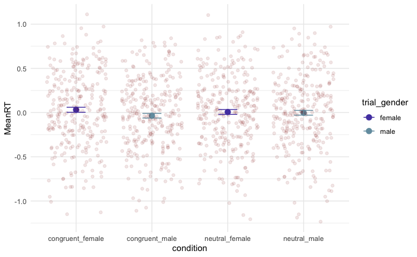

```r
all_data %>%
  group_by(condition,trial_gender) %>%
  summarize(MeanRT = mean(resid_rt), CI.Low = ci.low(resid_rt), CI.High = ci.high(resid_rt)) %>%
  mutate(YMin = MeanRT - CI.Low, YMax = MeanRT + CI.High) %>%
  ggplot(aes(x=condition,y=MeanRT,color=trial_gender)) +
  geom_point(size=3) +
  geom_jitter(data = agg_speaker_mean_con, aes(y=MeanRT),alpha=.1,color='darkred') +
  geom_errorbar(aes(ymin=YMin,ymax=YMax), width=.25) +
  scale_color_manual(values = inauguration_2021, ) +
  theme_minimal()
```

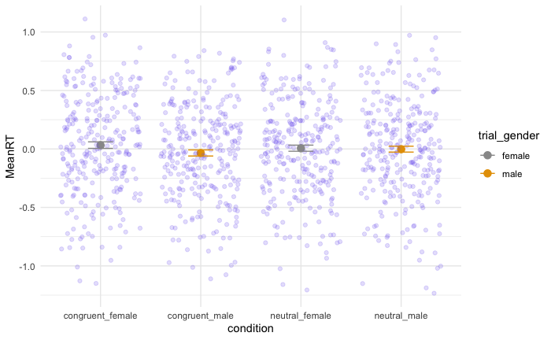

```r
all_data %>%
  group_by(condition,trial_gender) %>%
  summarize(MeanRT = mean(resid_rt), CI.Low = ci.low(resid_rt), CI.High = ci.high(resid_rt)) %>%
  mutate(YMin = MeanRT - CI.Low, YMax = MeanRT + CI.High) %>%
  ggplot(aes(x=condition,y=MeanRT,color=trial_gender)) +
  geom_point(size=3) +
  geom_jitter(data = agg_speaker_mean_con, aes(y=MeanRT),alpha=.2,color='mediumslateblue') +
  geom_errorbar(aes(ymin=YMin,ymax=YMax), width=.25) +
  scale_color_manual(values = cbPalette) +
  theme_minimal()
```

## 4.3 Reading Time by Gender Ideology

```r
aggr_speaker <- all_data %>%
  group_by(gender_link,workerid,trial_gender,trial_congruency) %>%
  summarise(meanrt = mean(resid_rt))
```

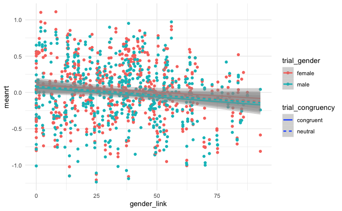

```r
aggr_speaker %>%
  ggplot(aes(x=gender_link,y=meanrt,color=trial_gender,linetype=trial_congruency)) +
  geom_point() +
  geom_smooth(method='lm') +
  theme_minimal()
```

# 5 Model Analyses